# **Supplementaty PCS Documentation: Does increasing model complexity and incorporating additional variables improve the prediction ability and model transportability of live birth prediction models for

#### RF

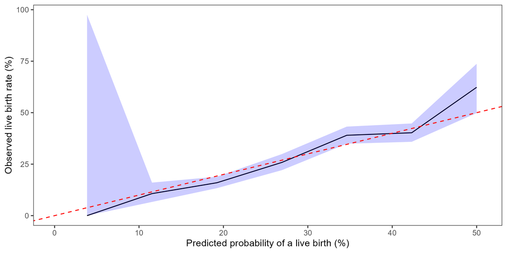

**Figure 23.** Calibration plot of the eight models predicting the probability of a live birth using donor eggs. Dotted red line represents optimal calibration where the predicted matches the observed outcome, black line is the model’s actual performance and shaded blue is the 95% CI of the models predicted value. CI is based on the binomial-based estimates for each predicted interval.

#### GAM

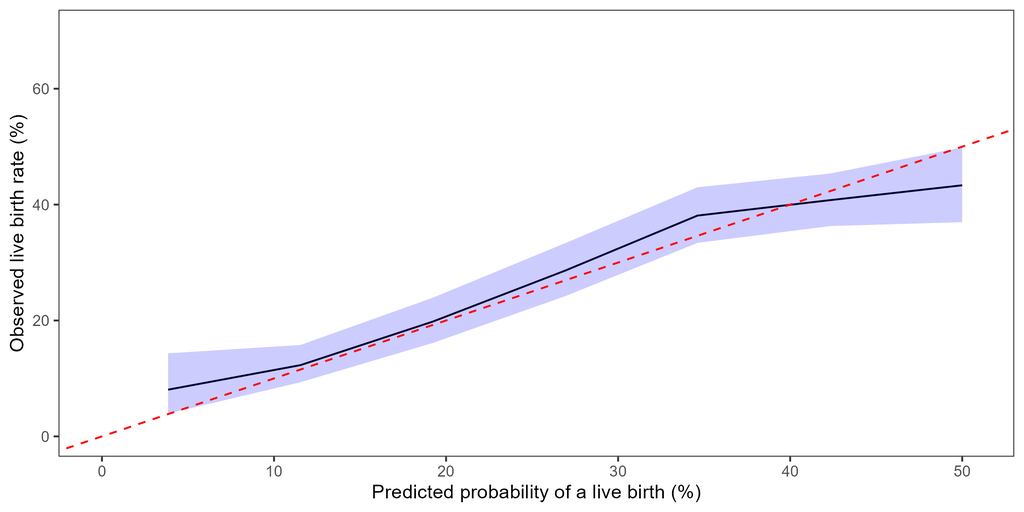

**Figure 24.** Calibration plot of the eight models predicting the probability of a live birth using donor eggs. Dotted red line represents optimal calibration where the predicted matches the observed outcome, black line is the model’s actual performance and shaded blue is the 95% CI of the models predicted value. CI is based on the binomial-based estimates for each predicted interval.

#### XGBoost

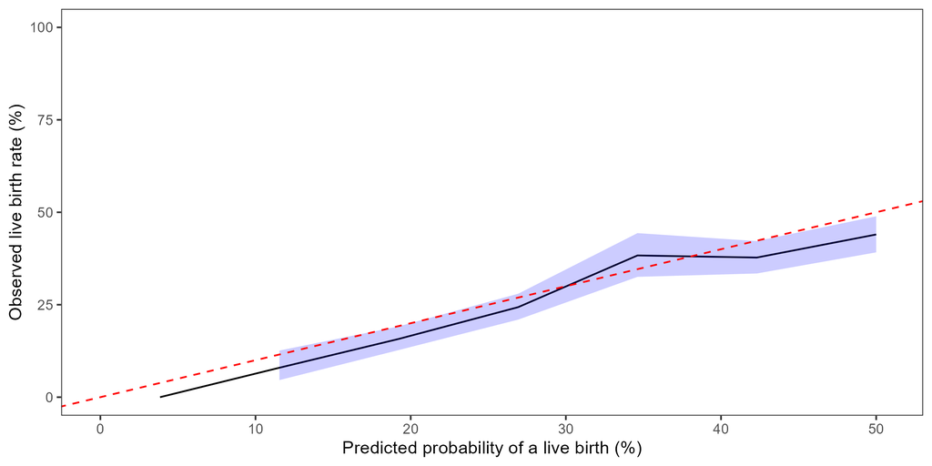

**Figure 25.** Calibration plot of the eight models predicting the probability of a live birth using donor eggs. Dotted red line represents optimal calibration where the predicted matches the observed outcome, black line is the model’s actual performance and shaded blue is the 95% CI of the models predicted value. CI is based on the binomial-based estimates for each predicted interval.

#### NN

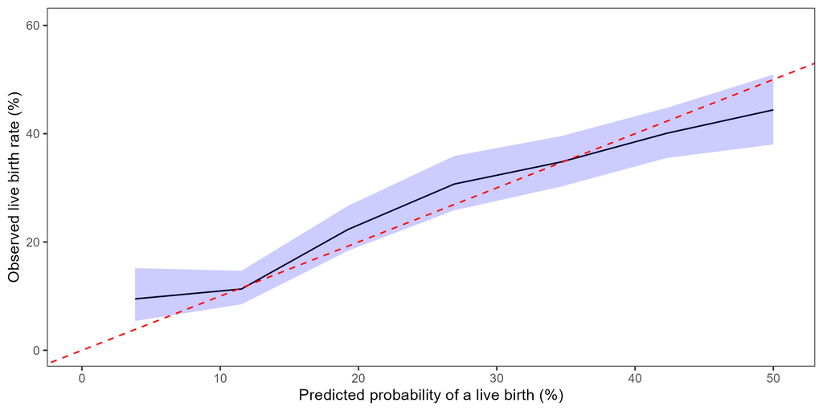

**Figure 26.** Calibration plot of the eight models predicting the probability of a live birth using donor eggs. Dotted red line represents optimal calibration where the predicted matches the observed outcome, black line is the model’s actual performance and shaded blue is the 95% CI of the models predicted value. CI is based on the binomial-based estimates for each predicted interval.

#### KNN

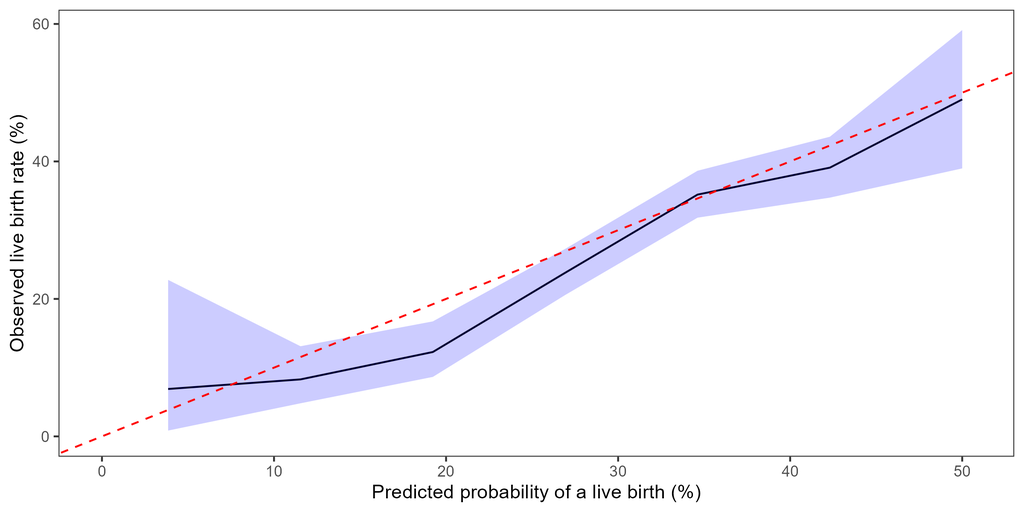

**Figure 27.** Calibration plot of the eight models predicting the probability of a live birth using donor eggs. Dotted red line represents optimal calibration where the predicted matches the observed outcome, black line is the model’s actual performance and shaded blue is the 95% CI of the models predicted value. CI is based on the binomial-based estimates for each predicted interval.

## **3.4 Interpretability**

To better understand the results of the prediction models, interpretable machine learning methods were applied to the models that had adequate prediction and stability performance, which in this case DT was excluded. Here, the permutation feature importance and accumulated local effects (ALE) was assessed on the test subset to see what was important in the model and how it impacted the prediction.

Permutation feature importance was done to determine which variables were important during the model’s decision making (Breiman, 2001). Importance was determined based on how much the prediction error increases after randomly shuffling the variables one by one. The more important the variable is, the larger the performance degradation. Error was measured based on the change in AUC-ROC, and AUC-ROC was chosen as it was one of the model evaluation metrics. To compare across the models, the feature importance was normalised, using min-max normalisation and averaged across the models. Normalising the numbers between 0 and 1 allows direct comparison across models which have different ranges in results. To get an understanding of the overall importance of the variable, an average was taken across all the models’ AUC-ROC error. Here we could collectively compare which variable was the most important across all models.

ALE plots were done to understand the local effects impact of a variable towards the model predictions. It uncovers certain relationships towards the prediction outcome such as positive/negative or non-linear effects. Histogram plots map the patient distribution on the ALE plots to visualise the distribution of the variable. The top 10 variables from the permutation feature importance analysis were selected for ALE analysis to further interpret the features influence on the model performance whilst maintaining a manageable number of visualisations. It enabled evaluation of the new candidate features to be visualised too.

# **4.Validation outcomes**

Overall, the stability analysis indicated that interpretable models like GAM and regLR had consistent performance across the test validation, external validation and reverse external validation (Table 8). These findings indicate that these interpretable models provided the best balance of predictive performance, stability and transportability.

Deep diving into the ALE plots, they were relatively in line with literature on the nature of the features influencing the live birth rate predictions of the models. For instance, as the number of recipient transfers were done, the less likely a live birth would occur, similar to recipient and donor egg age (Hogan et al., 2019; Williams et al., 2022; Zenke & Chetkowski, 2004). Positive predictors include the transfer of a blastocyst stage embryo, a fresh embryo transfer, the recipient having a previous pregnancy. The new variable, particularly female recipient BMI showed inverse relationship with BMI and live birth prediction(Fabozzi et al., 2024; Luke et al., 2014). And reciprocal ivf (female-female couple) showed higher rates of live birth. The consistency of these relationships across multiple models support the robustness and clinical plausibility of the variables.

## Test confusion matrix

**Table 4.** Confusion matrices for the final models during the held out test phase.

| Model | True Positive (TP) | False Positive (FP) | False Negative (FN) | True Negative (TN) |
| --- | --- | --- | --- | --- |
| LR | 10 | 20 | 710 | 1773 |
| RegLR | 10 | 16 | 710 | 1777 |
| DT | 220 | 379 | 500 | 1414 |
| RF | 12 | 16 | 708 | 1777 |
| KNN | 6 | 8 | 714 | 1785 |
| XGBoost | 40 | 51 | 680 | 1742 |
| GAM | 47 | 55 | 673 | 1738 |
| NN | 71 | 81 | 649 | 1712 |

## Test prediction outcomes

**Table 5.** Model prediction performance outcomes (95% CI) of the eight IVF prediction models trained on Australian treatments from the ANZARD dataset (2020–2024). Confidence intervals were calculated using 1,000 bootstrap resamples of the test dataset.

| Model | AUC-ROC (95% CI) | AUC-PR (95% CI) | Brier score (95% CI) |
| --- | --- | --- | --- |
| GAM | 0.668 (0.646–0.690) | 0.407 (0.375–0.442) | 0.190 (0.182–0.198) |
| RegLR | 0.667 (0.646–0.689) | 0.400 (0.370–0.433) | 0.190 (0.183–0.198) |
| RF | 0.666 (0.642–0.690) | 0.413 (0.383–0.448) | 0.191 (0.184–0.198) |
| NN | 0.668 (0.645–0.690) | 0.401 (0.370–0.432) | 0.191 (0.183–0.199) |
| LR | 0.666 (0.643–0.688) | 0.398 (0.365–0.432) | 0.191 (0.184–0.198) |
| XGB | 0.665 (0.643–0.687) | 0.404 (0.372–0.439) | 0.192 (0.185–0.199) |
| KNN | 0.656 (0.633–0.677) | 0.400 (0.369–0.437) | 0.193 (0.186–0.200) |
| YourIVFSuccess Estimator tested on updated data | 0.659 (0.637–0.680) | 0.398 (0.366–0.432) | 0.194 (0.187–0.202) |
| DT | 0.604 (0.579–0.628) | 0.356 (0.327–0.387) | 0.237 (0.226–0.249) |

Abbreviations: AUC-ROC, area under the receiver operating characteristic curve; AUC-PR, area under the precision–recall curve; CI, confidence interval. Confidence intervals were estimated using 1,000 bootstrap resamples of the test dataset. Models are presented in descending order of overall predictive performance. The best-performing model(s) for each metric are shown in bold.

## External validation outcomes

**Table 6.** Model prediction performance outcomes (95% CI) of the eight IVF prediction models externally validated on the New Zealand dataset (2020–2024). Confidence intervals were estimated using 1,000 bootstrap resamples of the test dataset.

| Model | AUC-ROC (95% CI) | AUC-PR (95% CI) | Brier score (95% CI) |
| --- | --- | --- | --- |
| GAM | 0.671 (0.615–0.734) | 0.441 (0.359–0.548) | 0.200 (0.182–0.217) |
| LR | 0.671 (0.615–0.732) | 0.432 (0.355–0.531) | 0.202 (0.184–0.218) |
| RegLR | 0.669 (0.608–0.727) | 0.427 (0.350–0.522) | 0.201 (0.184–0.219) |
| YourIVFSuccess Estimator tested on updated data | 0.660 (0.598–0.721) | 0.415 (0.334–0.510) | 0.202 (0.182–0.221) |
| KNN | 0.645 (0.583–0.709) | 0.402 (0.318–0.493) | 0.204 (0.192–0.217) |
| RF | 0.625 (0.563–0.687) | 0.395 (0.320–0.494) | 0.208 (0.193–0.224) |
| NN | 0.623 (0.564–0.685) | 0.378 (0.303–0.459) | 0.227 (0.203–0.250) |
| XGB | 0.596 (0.533–0.657) | 0.367 (0.294–0.454) | 0.226 (0.206–0.246) |

Abbreviations: AUC-ROC, area under the receiver operating characteristic curve; AUC-PR, area under the precision–recall curve; CI, confidence interval. Confidence intervals were estimated using 1,000 bootstrap resamples of the test dataset. Models are presented in descending order of overall predictive performance. The best-performing model(s) for each metric are shown in bold.

## Reverse external validation outcomes

**Table 7.** Reverse external validation performance outcomes (95% CI) of the IVF prediction models trained on the New Zealand dataset and evaluated on the Australian dataset (2020–2024). Confidence intervals were estimated using 1,000 bootstrap resamples of the test dataset.

| Model | AUC-ROC (95% CI) | AUC-PR (95% CI) | Brier score (95% CI) |
| --- | --- | --- | --- |
| RegLR | 0.659 (0.647–0.671) | 0.390 (0.372–0.407) | 0.203 (0.199–0.207) |
| GAM | 0.656 (0.643–0.668) | 0.384 (0.367–0.402) | 0.199 (0.195–0.203) |
| KNN | 0.654 (0.642–0.666) | 0.386 (0.370–0.404) | 0.199 (0.197–0.202) |
| RF | 0.630 (0.617–0.642) | 0.372 (0.355–0.389) | 0.200 (0.197–0.203) |
| LR | 0.631 (0.619–0.644) | 0.362 (0.345–0.381) | 0.201 (0.196–0.205) |
| XGB | 0.628 (0.615–0.641) | 0.363 (0.347–0.381) | 0.211 (0.207–0.214) |
| NN | 0.600 (0.588–0.614) | 0.341 (0.325–0.357) | 0.227 (0.222–0.232) |

Abbreviations: AUC-ROC, area under the receiver operating characteristic curve; AUC-PR, area under the precision–recall curve; CI, confidence interval. Confidence intervals were estimated using 1,000 bootstrap resamples of the test dataset. Models are presented in descending order of overall predictive performance. The best-performing model(s) for each metric are shown in bold.

## Model stability across Validation scenarios

**Table 8.** Stability of model performance across external validation scenarios

| Model | Mean abs Δ AUC-ROC AUC-ROC | Mean abs Δ AUC-ROC ROC Rank | Mean abs Δ AUC-PR AUC-PR | Mean abs Δ AUC-PR PR Rank | Mean abs Δ Brier Brier | Mean abs Δ Brier Brier Rank | Overall Mean Stability Rank |
| --- | --- | --- | --- | --- | --- | --- | --- |
| RegLR | 0.005 | 1 | 0.019 | 2 | 0.008 | 1 | 1.33 |
| KNN | 0.006 | 2 | 0.008 | 1 | 0.012 | 4 | 2.33 |
| GAM | 0.008 | 3 | 0.029 | 3 | 0.010 | 2 | 2.67 |
| RF | 0.039 | 6 | 0.030 | 4 | 0.011 | 3 | 4.33 |
| LR | 0.020 | 4 | 0.035 | 6 | 0.013 | 5 | 5.00 |
| DT | 0.030 | 5 | 0.035 | 5 | 0.019 | 6 | 5.33 |
| XGB | 0.053 | 7 | 0.039 | 7 | 0.027 | 7 | 7.00 |
| NN | 0.057 | 8 | 0.042 | 8 | 0.036 | 8 | 8.00 |

Model stability was assessed using the mean absolute change (|Δ|) in each performance metric from internal validation across the external and reverse external validation scenarios. Smaller mean absolute changes indicate greater stability. Models were ranked separately for AUC-ROC, AUC-PR and Brier score, with rank 1 indicating the greatest stability. The mean stability rank represents the average of the three metric-specific ranks, with lower values indicating greater overall stability.

# **5.Conclusion**

To conclude, increasing model complexity did not improve prediction performance and model transportability compared to more interpretable models like GAM. However, by incorporating additional variables, it did improve the model performance over the current YourIVFSuccess Estimator while providing the opportunity to make the YourIVFSuccess Estimator more personalised. Particularly, recipient BMI and sex of the intending parents emerged as promising variables. Although these findings are based on some newly collected variables, further validation would be beneficial once more data becomes available. Overall, the study demonstrates that interpretable transparent models can provide a robust and trustworthy clinical decision aid for donor egg IVF.

# **6.Bibliography**

Bichri, H., Chergui, A., & Hain, M. (2024). Investigating the Impact of Train/Test Split Ratio on the Performance of Pre-Trained Models with Custom Datasets. International Journal of Advanced Computer Science & Applications, 15(2).

Breiman, L. (2001). Random forests. Machine learning, 45, 5–32.

Dowle, M., Srinivasan, A., Gorecki, J., Chirico, M., Stetsenko, P., Short, T., Lianoglou, S., Antonyan, E., Bonsch, M., & Parsonage, H. (2019). Package ‘data. table’. Extension of ’data. frame, 596, 952.

Fabozzi, G., Cimadomo, D., Maggiulli, R., Vaiarelli, A., Badajoz, V., Aura, M., Canosa, S., Bongioanni, F., Benini, F., Livi, C., Zacà, C., Borini, A., Alviggi, E., Iussig, B., Hebles, M., Sànchez, P., Cimadomo, V., Rienzi, L., & Llàcer, J. (2024). Association between oocyte donors’ or recipients’ body mass index and clinical outcomes after first single blastocyst transfers-the uterus is the most affected. Fertil Steril, 121(2), 281–290. https://doi.org/10.1016/j.fertnstert.2023.07.029

Fitzgerald, O., Newman, J., Rombauts, L., Polyakov, A., & Chambers, G. M. (2024). Development of an IVF prediction model for donor oocytes: a retrospective analysis of 10 877 embryo transfers. Human Reproduction, deae174.

Foster, K. E., Lee, T. A. K., & Johnson, K. W. H. N. R. K. W. B. (2023). rsample: Simplifying Resampling for Machine Learning. R package version 1.1.0. https://CRAN.R-project.org/package=rsample

Hadley, W., Romain, F., Lionel, H., & Kirill, M. (2023). tibble: Simple Data Frames. RStudio. Retrieved 18/10/2024 from https://cran.r-project.org/web/packages/tibble/index.html

Helen R. Sofaer, J. A. H., Catherine S. Jarnevich. (2018). The area under the precision-recall curve as a performance metric for rare binary events. British Ecological Society, 10(4), 565–577.

Hogan, R. G., Wang, A. Y., Li, Z., Hammarberg, K., Johnson, L., Mol, B. W., & Sullivan, E. A. (2019). Oocyte donor age has a significant impact on oocyte recipients’ cumulative live-birth rate: a population-based cohort study. Fertility and Sterility, 112(4), 724–730.

James Otto, D. K. (2023). Interpretable Bivariate Density Visualization with ‘ggplot2’.

Johns, M. V. (1988). Importance sampling for bootstrap confidence intervals. Journal of the American Statistical Association, 83(403), 709–714.

Kim, J.-H. (2009). Estimating classification error rate: Repeated cross-validation, repeated hold-out and bootstrap. Computational statistics & data analysis, 53(11), 3735–3745.

Kuhn, M. (2023). Caret: Classification and Regression Training. Retrieved 18/10/2024 from https://CRAN.R-project.org/package=caret Kuhn, M., & Wickham, H. (2024). recipes: Preprocessing Tools to Create Design Matrices. R Core Team. Retrieved 18/10/2024 from https://cran.r-project.org/web/packages/recipes/index.html

Luke, B., Brown, M. B., Wantman, E., Stern, J. E., Baker, V. L., Widra, E., Coddington III, C. C., Gibbons, W. E., & Ball, G. D. (2014). A prediction model for live birth and multiple births within the first three cycles of assisted reproductive technology. Fertility and sterility, 102(3), 744–752.

McShane, B. B., & Albert, P. W. (2022). Metrics: Evaluation Metrics for Machine Learning. The R Foundation for Statistical Computing. Retrieved 18/10/2024 from https://cran.r-project.org/web/packages/Metrics/index.html

Molnar, C. (2022). Interpretable Machine Learning: R Package Documentation for ‘iml’. GitHub Repository. https://cran.r-project.org/web/packages/iml/index.html

Nathan, U., Martin, M., V, L. R., Achim, Z., Paul-Christian, B., & Philippe, G. (2021). pproc: Piecewise Polynomial Regression. The R Foundation for Statistical Computing. https://CRAN.R-project.org/package=pproc

Nguyen, Q. H., Ly, H.-B., Ho, L. S., Al-Ansari, N., Le, H. V., Tran, V. Q., Prakash, I., & Pham, B. T. (2021). Influence of Data Splitting on Performance of Machine Learning Models in Prediction of Shear Strength of Soil. Mathematical Problems in Engineering, 2021(1), 4832864. https://doi.org/https://doi.org/10.1155/2021/4832864

Sachs, M. C. (2017). plotROC: A Tool for Plotting ROC Curves. Journal of Statistical Software, Code Snippets, 79, 1–19.

Spinu, V., Grolemund, G., & Wickham, H. (2023). Lubridate: Make Dealing with Dates a Little Easier. RStudio, PBC. https://cran.r-project.org/web/packages/lubridate/index.html

Tierney, N. (2023). naniar: Data Structures, Summaries, and Visualisations for Missing Data. R package. Retrieved 18/10/2024 from https://CRAN.R-project.org/package=naniar

Toloşi, L., & Lengauer, T. (2011). Classification with correlated features: unreliability of feature ranking and solutions. Bioinformatics, 27(14), 1986–1994.

Wickham, H., Chang, W., & Wickham, M. H. (2016). Package ‘ggplot2’. Create elegant data visualisations using the grammar of graphics. Version, 2(1), 1–189.

Wickham, H., François, R., Henry, L., & Müller, K. (2023). dplyr: A Grammar of Data Manipulation. R Foundation for Statistical Computing. Retrieved 18/10/2024 from https://cran.r-project.org/package=dplyr

Wilke, C. O. (2024). Streamlined Plot Theme and Plot Annotations for ‘ggplot2’. Retrieved 5/11/2024 from https://cran.r-project.org/web/packages/cowplot/vignettes/introduction.html

Williams, R. S., Ellis, D. D., Wilkinson, E. A., Kramer, J. M., Datta, S., & Guzick, D. S. (2022). Factors affecting live birth rates in donor oocytes from commercial egg banks vs. program egg donors: an analysis of 40,485 cycles from the Society for Assisted Reproductive Technology registry in 2016–2018. Fertility and Sterility, 117(2), 339–348.

Yu, B., & Kumbier, K. (2020). Veridical data science. Proceedings of the National Academy of Sciences, 117(8), 3920–3929. https://doi.org/doi:10.1073/pnas.1901326117

Zenke, U., & Chetkowski, R. J. (2004). Transfer and uterine factors are the major recipient-related determinants of success with donor eggs. Fertility and sterility, 82(4), 850–856.